# Warsztaty Badawcze Praca domowa 1

Martyna Majchrzak

16 03 2020

# 1 Eksploracja Danych

Dane zawierają informacje z profili randkowych użytkowników aplikacji OkCupid z San Francisco, 2015 rok. Zmienna celu opisuje, czy dany użytkownik pracuje w STEM (Science, Technology, Engineering, Mathematics), czy nie, lub też czy jest studentem.

```r
str(data_okcupid)
```

```
## 'data.frame':    50789 obs. of  21 variables:
##  $ age        : num  22 35 23 29 29 31 37 28 24 30 ...
##  $ body_type  : Factor w/ 12 levels "a little extra",..: 1 3 11 2 3 3 2 3 NA 10 ...
##  $ diet       : Factor w/ 18 levels "anything","halal",..: 11 7 18 NA 4 4 4 4 NA 4 ...
##  $ drinks     : Factor w/ 6 levels "desperately",..: 5 3 5 5 5 5 2 5 3 5 ...
##  $ drugs      : Factor w/ 3 levels "never","often",..: 1 3 NA 1 NA 1 1 1 NA 1 ...
##  $ education  : Factor w/ 32 levels "college/university",..: 25 31 25 10 10 10 32 10 NA 11 ...
##  $ ethnicity  : Factor w/ 208 levels "asian","asian, black",..: 96 207 207 22 207 207 207 207 207 207 ...
##  $ height     : num  75 70 71 66 67 65 65 72 72 66 ...
##  $ income     : Factor w/ 12 levels "20000","30000",..: NA 7 1 NA NA NA NA 3 NA 2 ...
##  $ job        : Factor w/ 3 levels "stem","non_stem",..: 2 2 3 2 1 2 3 2 2 2 ...
##  $ last_online: chr  "2012-06-28-20-30" "2012-06-29-21-41" "2012-06-28-14-22" "2012-06-27-21-26" ...
##  $ location   : Factor w/ 184 levels "alameda, california",..: 161 108 15 142 142 142 148 41 142 142 ...
##  $ offspring  : Factor w/ 15 levels "doesn&rsquo;t have kids",..: 3 3 5 NA 3 4 NA NA 1 NA ...
##  $ orientation: Factor w/ 3 levels "bisexual","gay",..: 3 3 3 3 3 3 3 3 3 3 ...
##  $ pets       : Factor w/ 15 levels "dislikes cats",..: 15 15 11 15 11 15 15 11 NA 10 ...
##  $ religion   : Factor w/ 45 levels "agnosticism",..: 4 5 NA NA 6 21 7 24 41 25 ...
##  $ sex        : Factor w/ 2 levels "f","m": 2 2 2 2 2 1 2 2 2 1 ...
##  $ sign       : Factor w/ 48 levels "aquarius","aquarius and it matters a lot",..: 17 9 29 1 41 33 12 24 41 NA ...
##  $ smokes     : Factor w/ 5 levels "no","sometimes",..: 2 1 1 1 1 1 1 1 NA 1 ...
##  $ speaks     : Factor w/ 7019 levels "1","2","3","4",..: 1 2 3 1 4 5 6 7 1 1 ...
##  $ status     : Factor w/ 5 levels "available","married",..: 4 4 4 4 4 4 4 3 4 4 ...
```

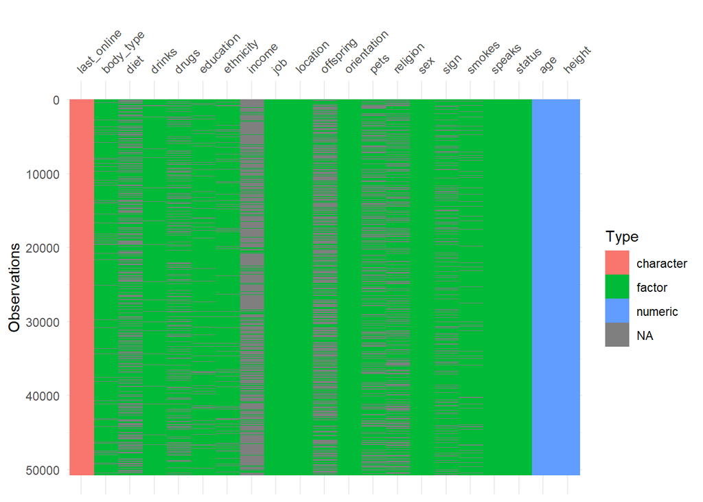

```r
visdat::vis_dat(data_okcupid, warn_large_data=FALSE)
```

Dane zawierają jedną kolumną, która jest typu character - last_online. Ponieważ ramka już i tak jest duża (21 kolumn), zdecydowałam się na całkowite usunięcie tej kolumny.

```r
data_okcupid<-data_okcupid[,-11]

naniar::miss_var_summary(data_okcupid)
```

| variable | n_miss | pct_miss |
| --- | --- | --- |
| income | 39886 | 78.53275316 |
| offspring | 28914 | 56.92965012 |
| diet | 19382 | 38.16180669 |
| religion | 15126 | 29.78203942 |
| pets | 14938 | 29.41188053 |
| drugs | 11622 | 22.88290772 |
| sign | 7700 | 15.16076316 |
| ethnicity | 3989 | 7.85406289 |
| body_type | 3905 | 7.68867274 |
| smokes | 3572 | 7.03301896 |

[output cut: 10 more lines]

Najwięcej braków danych znajduje się w kolumnie income. Zobaczmy jak wygląda ich rozkład w podziale na zmienna job.

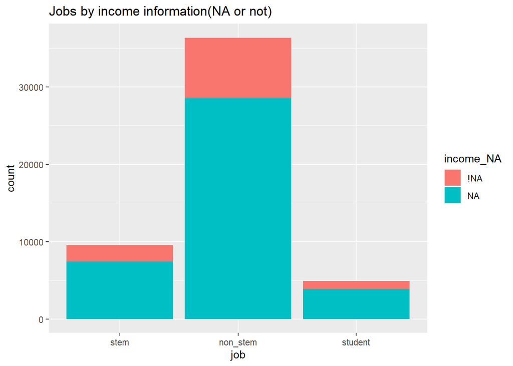

```r
data_okcupid %>%
  bind_shadow() %>%
  ggplot(aes(x = job,
             fill = income_NA )) +
  geom_bar()+
  ggtitle("Jobs by income information(NA or not)")
```

Przy okazji widać, że zmienna celu job jest niezbyt zbilansowana, ale nie ma dramatu.

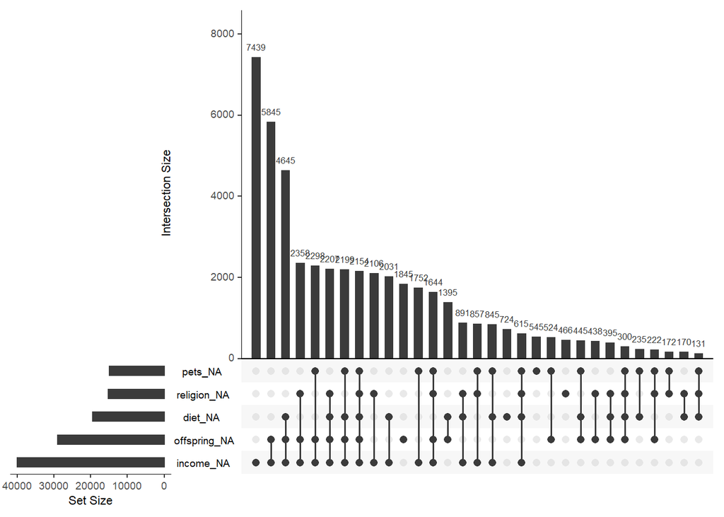

```r
naniar::gg_miss_upset(data_okcupid)
```

Wygląda na to, że braki są dosyć losowo rozmieszczone.

# 2 Podział na zbiór treningowy i testowy

Za target przyjmiemy zmienną ‘job’, a następnie podzielimy zbiór w proporcji: treningowy 80% i testowy 20%.

```r
train_set<-sample(nrow(data_okcupid), 0.8 * nrow(data_okcupid))
test_set<-setdiff(seq_len(nrow(data_okcupid)), train_set)
data_train <- data_okcupid[train_set,]
data_test <- data_okcupid[test_set,]
```

W kolumnach a wartościach numerycznych (age, height) znajduje się tylko jedno NA - w kolumnie height

Zastosujemy teraz zastępujący proces:

# 3 Metoda 1 - usunięcie wierszy z NA

## 3.1 Imputacja

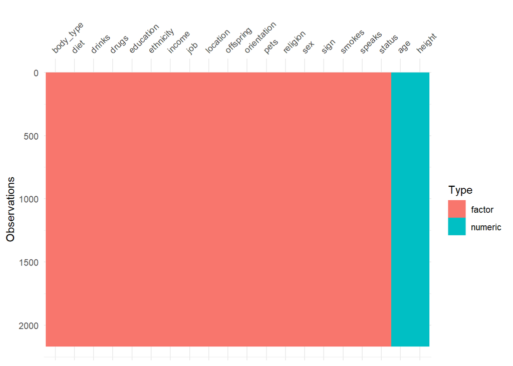

```r
data_okcupid1<-na.omit(data_okcupid)
# train_set1<-intersect(rownames(data_okcupid1),train_set)
# test_set1<-intersect(rownames(data_okcupid1), test_set)

train_set1 <- intersect(seq_len(nrow(data_okcupid))[complete.cases(data_okcupid)], train_set)
test_set1 <- intersect(seq_len(nrow(data_okcupid))[complete.cases(data_okcupid)], test_set)

visdat::vis_dat(rbind(data_okcupid1), warn_large_data=FALSE)
```

Pozostaje 2 167 obserwacji (z oryginalnych 50 789).

## 3.2 Model

```r
#Zdefiniowanie zadania
task_okcupid1 = mlr3::TaskClassif$new(id = "okcupid1", backend = data_okcupid, target = "job")

# wybór algorytmu
learner_okcupid1 = mlr_learners$get("classif.ranger")
learner_okcupid1$train(task_okcupid1, row_ids = train_set1)
# print(learner_okcupid1$model)

# predykcja
prediction_okcupid1 = learner_okcupid1$predict(task_okcupid1, row_ids = test_set1)
# print(prediction_okcupid1)
```

## 3.3 Wyniki

```r
prediction_okcupid1$confusion
```

```
##           truth
## response   stem non_stem student
##   stem       19        6       1
##   non_stem   47      282      31
##   student     1       12      11
```

```r
prediction_okcupid1$score(msr("classif.acc"))
```

```
## classif.acc
##   0.7609756
```

# 4 Metoda 2 - usunięcie kolumn z NA

## 4.1 Imputacja

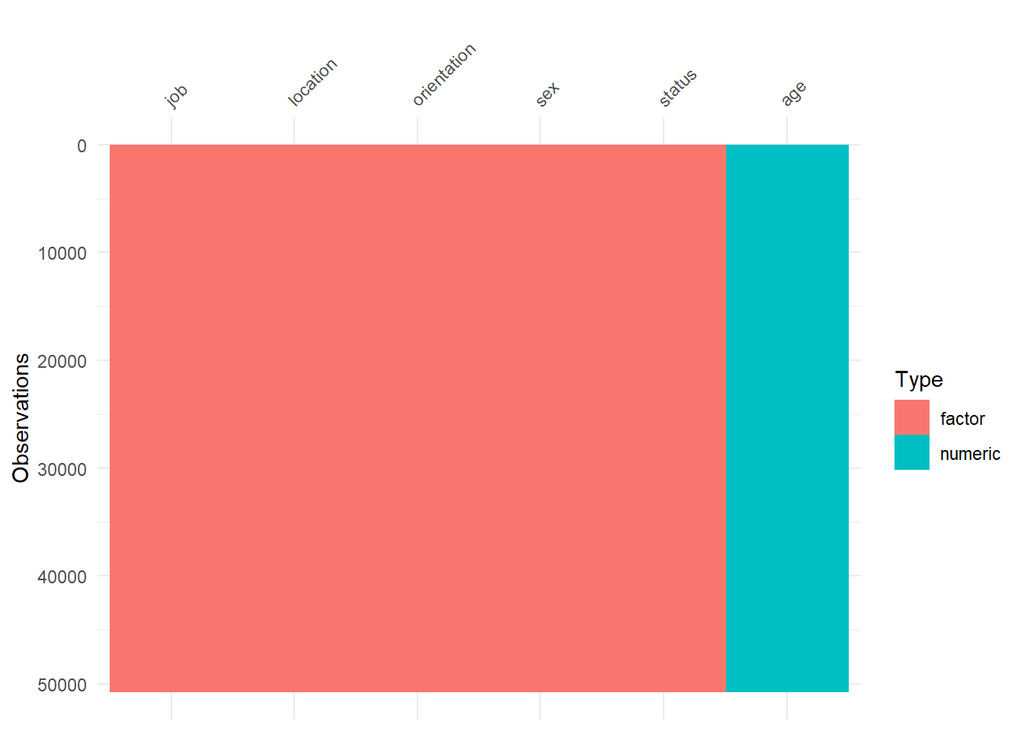

```r
data_okcupid_2<-data_okcupid[,c(1,10,11,13,16,20)]
train_set2<-train_set
test_set2<-test_set
visdat::vis_dat(data_okcupid_2, warn_large_data=FALSE)
```

Pozostaje 6 kolumn (z oryginalnych 20).

## 4.2 Model

```r
#Zdefiniowanie zadania
task_okcupid2 = mlr3::TaskClassif$new(id = "okcupid2", backend = data_okcupid_2, target = "job")

# wybór algorytmu
learner_okcupid2 = mlr_learners$get("classif.ranger")
learner_okcupid2$train(task_okcupid2, row_ids = train_set2)
# print(learner_okcupid1$model)

# predykcja
prediction_okcupid2 = learner_okcupid2$predict(task_okcupid2, row_ids = test_set2)
# print(prediction_okcupid2)
```

## 4.3 Wyniki

```r
prediction_okcupid2$confusion
```

```
##           truth
## response   stem non_stem student
##   stem        4        5       0
##   non_stem 1812     7216     813
##   student    10      118     180
```

```r
prediction_okcupid2$score(msr("classif.acc"))
```

```
## classif.acc
##   0.7284899
```

# 5 Metoda 3 - w zmiennych kategorycznych moda, a numerycznych średnia

## 5.1 Imputacja

```r
data_okcupid3<-data_okcupid

# zastąpienie NA w height średnią
data_okcupid3 <- mutate(data_okcupid3,
                     height=ifelse(is.na(height),
                                   mean(na.omit(height)),
                                   height))

# zastąpienie NA w pozostałych zmiennych modą

factors_with_NAs <- unlist(lapply(data_okcupid, function(x) any(is.na(x))))
factors_with_NAs <- names(factors_with_NAs)[factors_with_NAs]

for(f in factors_with_NAs) {
  data_okcupid3[[f]] <- ifelse(is.na(data_okcupid3[[f]]),
                             mode(data_okcupid3[[f]]),
                             data_okcupid3[[f]])

}
```

## 5.2 Model

```r
#Zdefiniowanie zadania
task_okcupid3 = mlr3::TaskClassif$new(id = "okcupid3", backend = data_okcupid3, target = "job")

# wybór algorytmu
learner_okcupid3 = mlr_learners$get("classif.ranger")
learner_okcupid3$train(task_okcupid3, row_ids = train_set)
# print(learner_okcupid1$model)

# predykcja

prediction_okcupid3 = learner_okcupid3$predict(task_okcupid3, row_ids = test_set)
# print(prediction_okcupid2)
```

## 5.3 Wyniki

```r
prediction_okcupid3$confusion
```

```
##           truth
## response   stem non_stem student
##   stem      277      183      13
##   non_stem 1502     6915     542
##   student    47      241     438
```

```r
prediction_okcupid3$score(msr("classif.acc"))
```

```
## classif.acc
##   0.7511321
```

# 6 Podsumowanie

Ze względu na to, że zmienna celu ma 3 poziomy (stem/non_stem/student), że możemy tu użyć poznanych na zajęciach narzędzi do oceny, bo nie wiadomo który poziom jest ‘positive’. Można rozważyć usunięcie do analizy obserwacji zakwalifikowanych jako ‘student’, jako najmniej licznej, lub połączenie kategorii stem i student.

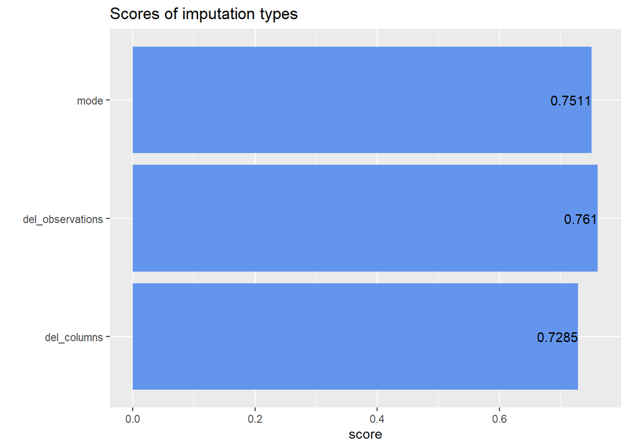

```r
delete_observations<-as.numeric(prediction_okcupid1$score(msr("classif.acc")))
delete_columns<-as.numeric(prediction_okcupid2$score(msr("classif.acc")))
mode<-as.numeric(prediction_okcupid3$score(msr("classif.acc")))

scores<-data.table(c("del_observations", "del_columns", "mode"),
                   c(delete_observations,delete_columns, mode))
colnames(scores)<-c("imputation_type", "score")

ggplot(scores, aes(imputation_type, score))+
  geom_col(fill="cornflowerblue")+
  geom_text(aes(label = round(score,4)), hjust=1)+
  ggtitle("Scores of imputation types")+
  coord_flip()+
  xlab("")
```